# Localized Sedimentation Analysis

Ross Cunning

2026-10-01

```r
library(tidyverse)
library(readxl)
library(janitor)
library(ggrepel)
library(ggspatial)

project_dir <- if (basename(getwd()) == "code") dirname(getwd()) else getwd()
knitr::opts_knit$set(root.dir = project_dir)
knitr::opts_chunk$set(
  echo = TRUE,
  message = FALSE,
  warning = FALSE,
  fig.align = "center"
)
```

## Data sources

```r
sediment_dir <- "data/sedimentation_monitoring"
gps_file <- file.path(sediment_dir, "PE_SB_Station_Transect_GPS.xlsx")

normalize_transect_id <- function(x) {
  x %>%
    str_squish() %>%
    str_replace_all("\\s+", "_")
}

model_sedimentation_class <- function(transect) {
  case_when(
    transect %in% c("ST22", "ST31") ~ "1.0 cm predicted",
    transect %in% c("ST28", "ST5") ~ "1.5 mm predicted",
    TRUE ~ "0 cm predicted"
  ) %>%
    factor(
      levels = c(
        "1.0 cm predicted",
        "1.5 mm predicted",
        "0 cm predicted"
      ),
      ordered = TRUE
    )
}

construction_files <- list.files(
  file.path(sediment_dir, "2_During-Construction", "Data"),
  pattern = "\\.xlsx$",
  recursive = TRUE,
  full.names = TRUE
)

construction_file_index <- tibble(source_file = construction_files) %>%
  mutate(
    source_file_name = basename(source_file),
    construction_survey_n = map_int(
      str_extract_all(source_file_name, "(?i)(?<=con)\\d+"),
      ~ if (length(.x) == 0) NA_integer_ else max(as.integer(.x))
    )
  ) %>%
  filter(!is.na(construction_survey_n)) %>%
  arrange(desc(construction_survey_n), desc(file.info(source_file)$mtime))

latest_construction_file <- construction_file_index %>%
  slice(1) %>%
  pull(source_file)
```

```r
monitoring_transects <- read_excel(
  latest_construction_file,
  sheet = "SedimentDepth_RawData"
) %>%
  clean_names() %>%
  transmute(
    transect = normalize_transect_id(transect),
    transect_type = str_squish(transect_type)
  ) %>%
  distinct()

transect_gps <- read_excel(gps_file, sheet = "Hardbottom") %>%
  clean_names() %>%
  transmute(
    transect = normalize_transect_id(
      str_remove(station_transect_id, "\\s+\\d+m$")
    ),
    meter = as.integer(str_extract(station_transect_id, "\\d+(?=m$)")),
    gps_note = notes,
    lat_dd = as.numeric(lat_dd),
    lon_dd = as.numeric(lon_dd)
  ) %>%
  filter(!is.na(transect), !is.na(meter)) %>%
  arrange(transect, meter) %>%
  left_join(monitoring_transects, by = "transect") %>%
  mutate(model_sedimentation_class = model_sedimentation_class(transect))

transect_coverage <- full_join(
  monitoring_transects %>% mutate(in_monitoring_data = TRUE),
  transect_gps %>%
    summarize(
      n_gps_points = n(),
      min_meter = min(meter),
      max_meter = max(meter),
      coordinates_complete = all(!is.na(lat_dd) & !is.na(lon_dd)),
      .by = transect
    ) %>%
    mutate(in_gps_file = TRUE),
  by = "transect"
) %>%
  mutate(
    across(c(in_monitoring_data, in_gps_file), ~ replace_na(.x, FALSE)),
    map_ready = in_monitoring_data & in_gps_file & coordinates_complete
  ) %>%
  arrange(transect_type, transect)

stopifnot(
  nrow(monitoring_transects) == 19,
  all(transect_coverage$map_ready)
)

transect_coverage
```

```
## # A tibble: 19 × 9
##    transect transect_type in_monitoring_data n_gps_points min_meter max_meter
##    <chr>    <chr>         <lgl>                     <int>     <int>     <int>
##  1 ACER_NS  Adjacent      TRUE                          3         0       100
##  2 ACER_WE  Adjacent      TRUE                          2         0        50
##  3 BT23     Adjacent      TRUE                          2         0        70
##  4 BT23_S   Adjacent      TRUE                          3         0       100
##  5 BT24     Adjacent      TRUE                          2         0        70
##  6 BT24_N   Adjacent      TRUE                          3         0       100
##  7 ST1      Permanent     TRUE                          4         0       150
##  8 ST2      Permanent     TRUE                          2         0        50
##  9 ST22     Permanent     TRUE                          2         0        50
## 10 ST28     Permanent     TRUE                          2         0        50
## 11 ST31     Permanent     TRUE                          2         0        50
## 12 ST34     Permanent     TRUE                          2         0        50
## 13 ST35     Permanent     TRUE                          2         0        50
## 14 ST36     Permanent     TRUE                          2         0        50
## 15 ST38     Permanent     TRUE                          4         0       150
## 16 ST4      Permanent     TRUE                          2         0        50
## 17 ST40     Permanent     TRUE                          2         0        50
## 18 ST45     Permanent     TRUE                          2         0        50
## 19 ST5      Permanent     TRUE                          2         0        50
## # ℹ 3 more variables: coordinates_complete <lgl>, in_gps_file <lgl>,
## #   map_ready <lgl>
```

## Transect map

Lines connect the surveyed GPS anchors in meter order. Most 50 m transects have coordinates at both ends; longer and adjacent transects include intermediate anchors where they were supplied in the GPS workbook.

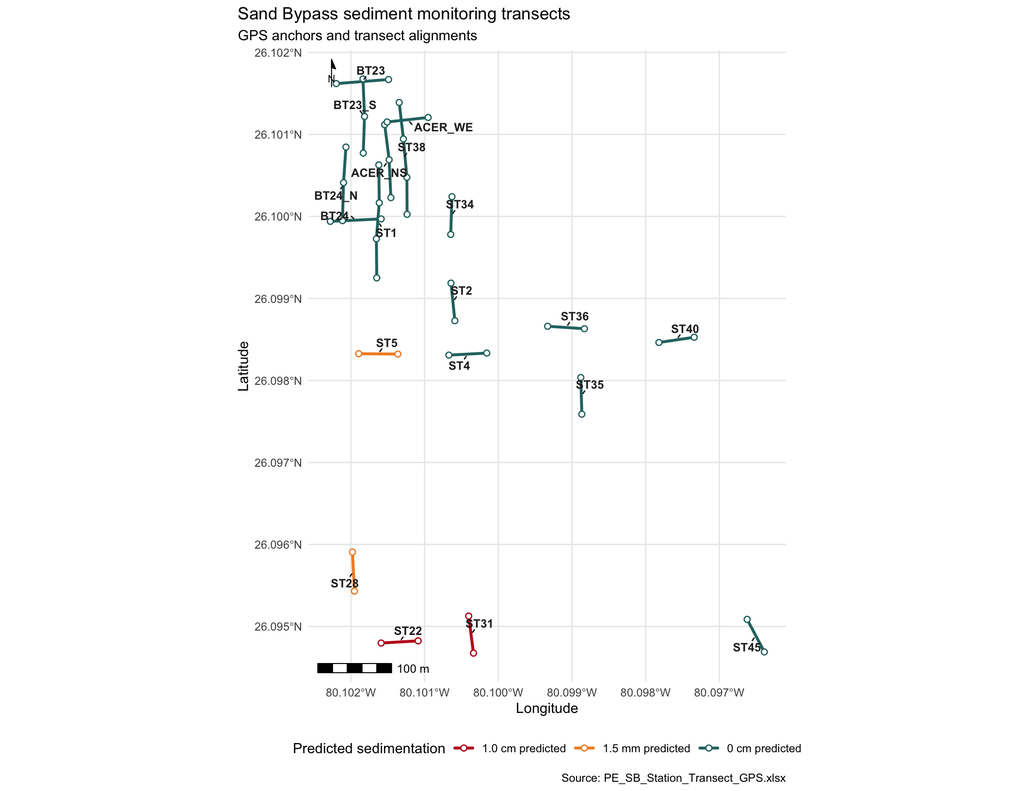

```r
transect_labels <- transect_gps %>%
  summarize(
    lon_dd = mean(range(lon_dd)),
    lat_dd = mean(range(lat_dd)),
    transect_type = first(transect_type),
    model_sedimentation_class = first(model_sedimentation_class),
    .by = transect
  )

transect_map <- ggplot(
  transect_gps,
  aes(
    x = lon_dd,
    y = lat_dd,
    group = transect,
    color = model_sedimentation_class
  )
) +
  geom_path(linewidth = 1.05, lineend = "round") +
  geom_point(size = 1.7, shape = 21, fill = "white", stroke = 0.7) +
  geom_text_repel(
    data = transect_labels,
    aes(label = transect),
    size = 3.2,
    fontface = "bold",
    color = "grey15",
    seed = 1406,
    box.padding = 0.3,
    point.padding = 0.15,
    force = 1.5,
    max.iter = 20000,
    min.segment.length = 0,
    max.overlaps = Inf,
    show.legend = FALSE
  ) +
  annotation_scale(
    location = "bl",
    width_hint = 0.22,
    text_cex = 0.75
  ) +
  annotation_north_arrow(
    location = "tl",
    which_north = "true",
    height = unit(0.75, "cm"),
    width = unit(0.75, "cm"),
    style = north_arrow_minimal(text_size = 8)
  ) +
  scale_color_manual(
    values = c(
      "1.0 cm predicted" = "#c1121f",
      "1.5 mm predicted" = "#f28e2b",
      "0 cm predicted" = "#287271"
    ),
    drop = FALSE
  ) +
  coord_sf(
    crs = sf::st_crs(4326),
    default_crs = sf::st_crs(4326),
    expand = TRUE,
    datum = sf::st_crs(4326)
  ) +
  labs(
    title = "Sand Bypass sediment monitoring transects",
    subtitle = "GPS anchors and transect alignments",
    x = "Longitude",
    y = "Latitude",
    color = "Predicted sedimentation",
    caption = "Source: PE_SB_Station_Transect_GPS.xlsx"
  ) +
  theme_minimal(base_size = 11) +
  theme(
    panel.grid.minor = element_blank(),
    legend.position = "bottom",
    legend.box = "vertical",
    plot.title.position = "plot"
  )

transect_map
```

## ST22 sediment deltas

For each survey, the three sediment-depth replicates are averaged at each meter position. The baseline mean at that same meter position is then subtracted from the construction-survey mean:

$$\Delta_{m,t} = \overline{x}_{m,t} - \overline{x}_{m,baseline}$$

Positive values indicate sediment accumulation relative to baseline. This meter-matched calculation retains spatial variation that would be lost by first averaging across the full transect.

```r
st22_raw <- read_excel(
  latest_construction_file,
  sheet = "SedimentDepth_RawData"
) %>%
  clean_names() %>%
  mutate(
    date = as.Date(date),
    survey = str_squish(survey),
    survey_n = if_else(
      survey == "Baseline",
      0L,
      as.integer(str_extract(survey, "\\d+"))
    ),
    transect = normalize_transect_id(transect),
    meter = as.integer(meter),
    meter_mean_sediment_cm = rowMeans(
      pick(starts_with("sed_depth_cm_")),
      na.rm = TRUE
    )
  ) %>%
  filter(transect == "ST22")

st22_baseline <- st22_raw %>%
  filter(survey == "Baseline") %>%
  transmute(
    meter,
    baseline_mean_sediment_cm = meter_mean_sediment_cm
  )

st22_meter_deltas <- st22_raw %>%
  filter(survey != "Baseline") %>%
  left_join(st22_baseline, by = "meter") %>%
  mutate(
    sediment_delta_cm =
      meter_mean_sediment_cm - baseline_mean_sediment_cm
  ) %>%
  select(
    date,
    survey,
    survey_n,
    transect,
    meter,
    baseline_mean_sediment_cm,
    meter_mean_sediment_cm,
    sediment_delta_cm
  ) %>%
  arrange(survey_n, meter)

st22_delta_coverage <- st22_meter_deltas %>%
  summarize(
    n_meter_positions = n(),
    n_missing_deltas = sum(is.na(sediment_delta_cm)),
    .by = c(date, survey, survey_n)
  ) %>%
  arrange(survey_n)

stopifnot(
  all(st22_delta_coverage$n_meter_positions == 51),
  all(st22_delta_coverage$n_missing_deltas == 0)
)

st22_delta_coverage
```

```
## # A tibble: 26 × 5
##    date       survey survey_n n_meter_positions n_missing_deltas
##    <date>     <chr>     <int>             <int>            <int>
##  1 2025-11-06 Con1          1                51                0
##  2 2025-11-17 Con2          2                51                0
##  3 2025-11-26 Con3          3                51                0
##  4 2025-12-05 Con4          4                51                0
##  5 2025-12-14 Con5          5                51                0
##  6 2025-12-29 Con6          6                51                0
##  7 2026-01-07 Con7          7                51                0
##  8 2026-01-17 Con8          8                51                0
##  9 2026-01-24 Con9          9                51                0
## 10 2026-02-05 Con10        10                51                0
## # ℹ 16 more rows
```

### Weekly density distributions

The density curves use a common horizontal scale. Fill colors classify the delta represented by each portion of the curve, rather than classifying an entire survey from a summary statistic.

```r
st22_delta_limits <- range(st22_meter_deltas$sediment_delta_cm) + c(-0.5, 0.5)

st22_density <- st22_meter_deltas %>%
  group_by(date, survey, survey_n) %>%
  group_modify(~ {
    density_estimate <- density(
      .x$sediment_delta_cm,
      from = st22_delta_limits[1],
      to = st22_delta_limits[2],
      n = 1024,
      na.rm = TRUE
    )

    tibble(
      sediment_delta_cm = density_estimate$x,
      density = density_estimate$y
    )
  }) %>%
  ungroup() %>%
  mutate(
    delta_band = case_when(
      sediment_delta_cm >= 1 ~ ">= 1 cm",
      sediment_delta_cm >= 0.5 ~ ">= 5 mm to < 1 cm",
      sediment_delta_cm >= 0.15 ~ ">= 1.5 mm to < 5 mm",
      TRUE ~ "< 1.5 mm"
    ),
    delta_band = factor(
      delta_band,
      levels = c(
        ">= 1 cm",
        ">= 5 mm to < 1 cm",
        ">= 1.5 mm to < 5 mm",
        "< 1.5 mm"
      )
    ),
    survey_label = paste0(
      survey,
      "\n",
      format(date, "%Y-%m-%d")
    ),
    survey_label = fct_reorder(survey_label, survey_n)
  )
```

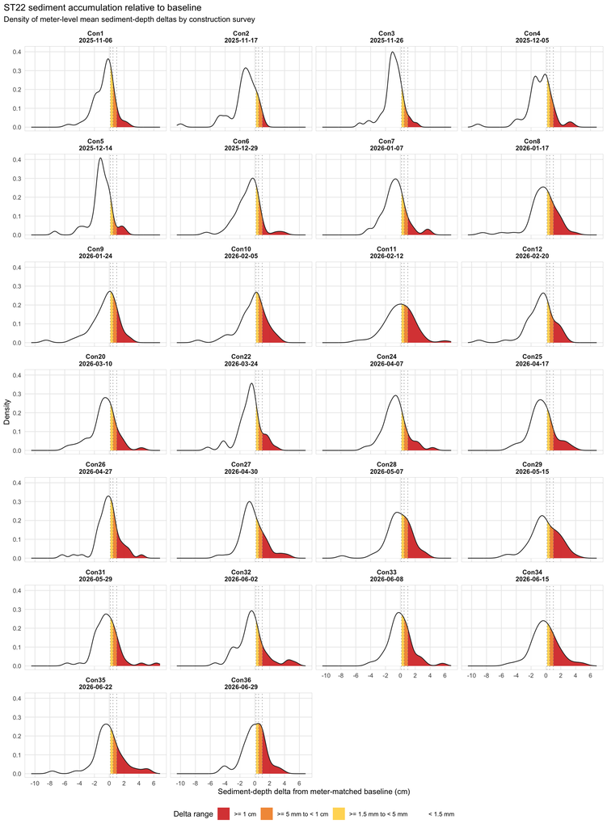

```r
st22_density_plot <- ggplot(
  st22_density,
  aes(x = sediment_delta_cm, y = density)
) +
  geom_area(
    aes(fill = delta_band, group = delta_band),
    color = NA,
    alpha = 0.9
  ) +
  geom_line(linewidth = 0.45, color = "grey15") +
  geom_vline(
    xintercept = c(0.15, 0.5, 1),
    color = "grey45",
    linewidth = 0.3,
    linetype = "dotted"
  ) +
  facet_wrap(~ survey_label, ncol = 4) +
  scale_fill_manual(
    values = c(
      ">= 1 cm" = "#d73027",
      ">= 5 mm to < 1 cm" = "#f28e2b",
      ">= 1.5 mm to < 5 mm" = "#ffd54f",
      "< 1.5 mm" = "white"
    ),
    drop = FALSE
  ) +
  scale_x_continuous(
    breaks = seq(
      floor(st22_delta_limits[1] / 2) * 2,
      ceiling(st22_delta_limits[2] / 2) * 2,
      by = 2
    )
  ) +
  labs(
    title = "ST22 sediment accumulation relative to baseline",
    subtitle = "Density of meter-level mean sediment-depth deltas by construction survey",
    x = "Sediment-depth delta from meter-matched baseline (cm)",
    y = "Density",
    fill = "Delta range"
  ) +
  theme_minimal(base_size = 10) +
  theme(
    panel.grid.minor = element_blank(),
    panel.border = element_rect(color = "grey80", fill = NA, linewidth = 0.3),
    strip.text = element_text(face = "bold", size = 8.5),
    legend.position = "bottom",
    plot.title.position = "plot"
  )

st22_density_plot
```

### Accumulation versus mirrored loss

This view compares accumulation and loss at the same absolute magnitude. The solid curve is the density at positive deltas. The dashed curve reflects the negative tail onto the positive axis. Colored ribbons show only magnitudes at which accumulation density is greater than the density of equivalent sediment loss. Where the dashed curve is higher, loss is more prevalent and no colored ribbon is drawn.

```r
st22_max_absolute_delta <-
  max(abs(st22_meter_deltas$sediment_delta_cm)) + 0.5

st22_mirrored_density <- st22_meter_deltas %>%
  group_by(date, survey, survey_n) %>%
  group_modify(~ {
    density_estimate <- density(
      .x$sediment_delta_cm,
      from = -st22_max_absolute_delta,
      to = st22_max_absolute_delta,
      n = 2049,
      na.rm = TRUE
    )

    positive_magnitude <- density_estimate$x[
      density_estimate$x >= 0
    ]

    tibble(
      magnitude_cm = positive_magnitude,
      accumulation_density = approx(
        density_estimate$x,
        density_estimate$y,
        xout = positive_magnitude
      )$y,
      mirrored_loss_density = approx(
        density_estimate$x,
        density_estimate$y,
        xout = -positive_magnitude
      )$y
    )
  }) %>%
  ungroup() %>%
  mutate(
    accumulation_exceeds_loss =
      accumulation_density > mirrored_loss_density,
    delta_band = case_when(
      magnitude_cm >= 1 ~ ">= 1 cm",
      magnitude_cm >= 0.5 ~ ">= 5 mm to < 1 cm",
      magnitude_cm >= 0.15 ~ ">= 1.5 mm to < 5 mm",
      TRUE ~ "< 1.5 mm"
    ),
    delta_band = factor(
      delta_band,
      levels = c(
        ">= 1 cm",
        ">= 5 mm to < 1 cm",
        ">= 1.5 mm to < 5 mm",
        "< 1.5 mm"
      )
    ),
    excess_run = cumsum(
      accumulation_exceeds_loss != lag(
        accumulation_exceeds_loss,
        default = first(accumulation_exceeds_loss)
      ) |
        delta_band != lag(delta_band, default = first(delta_band))
    ),
    survey_label = paste0(survey, "\n", format(date, "%Y-%m-%d")),
    survey_label = fct_reorder(survey_label, survey_n),
    .by = c(date, survey, survey_n)
  )

st22_mirrored_curves <- st22_mirrored_density %>%
  select(
    date,
    survey,
    survey_n,
    survey_label,
    magnitude_cm,
    accumulation_density,
    mirrored_loss_density
  ) %>%
  pivot_longer(
    c(accumulation_density, mirrored_loss_density),
    names_to = "curve",
    values_to = "density"
  ) %>%
  mutate(
    curve = recode(
      curve,
      accumulation_density = "Accumulation (+delta)",
      mirrored_loss_density = "Mirrored loss (-delta)"
    ),
    curve = factor(
      curve,
      levels = c("Accumulation (+delta)", "Mirrored loss (-delta)")
    )
  )

tail_balance_thresholds <- tribble(
  ~threshold_cm, ~threshold_label,
  0.15, "1.5 mm",
  0.5, "5 mm",
  1, "1 cm"
)

st22_weekly_tail_balance <- crossing(
  st22_meter_deltas,
  tail_balance_thresholds
) %>%
  summarize(
    n_meter_positions = n(),
    accumulation_fraction = mean(sediment_delta_cm >= threshold_cm),
    loss_fraction = mean(sediment_delta_cm <= -threshold_cm),
    tail_balance = accumulation_fraction - loss_fraction,
    .by = c(
      date,
      survey,
      survey_n,
      threshold_cm,
      threshold_label
    )
  ) %>%
  arrange(survey_n, threshold_cm)
```

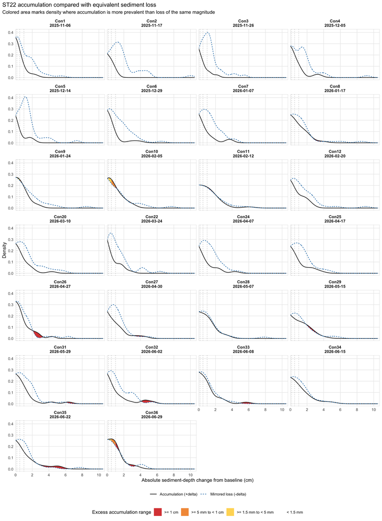

```r
st22_tail_balance_plot <- ggplot(
  st22_mirrored_curves,
  aes(x = magnitude_cm, y = density)
) +
  geom_ribbon(
    data = st22_mirrored_density %>%
      filter(accumulation_exceeds_loss),
    aes(
      x = magnitude_cm,
      ymin = mirrored_loss_density,
      ymax = accumulation_density,
      fill = delta_band,
      group = interaction(delta_band, excess_run)
    ),
    inherit.aes = FALSE,
    alpha = 0.9
  ) +
  geom_line(
    aes(color = curve, linetype = curve),
    linewidth = 0.55
  ) +
  geom_vline(
    xintercept = c(0.15, 0.5, 1),
    color = "grey55",
    linewidth = 0.3,
    linetype = "dotted"
  ) +
  facet_wrap(~ survey_label, ncol = 4) +
  scale_fill_manual(
    values = c(
      ">= 1 cm" = "#d73027",
      ">= 5 mm to < 1 cm" = "#f28e2b",
      ">= 1.5 mm to < 5 mm" = "#ffd54f",
      "< 1.5 mm" = "white"
    ),
    drop = FALSE
  ) +
  scale_color_manual(
    values = c(
      "Accumulation (+delta)" = "grey10",
      "Mirrored loss (-delta)" = "#2c7fb8"
    )
  ) +
  scale_linetype_manual(
    values = c(
      "Accumulation (+delta)" = "solid",
      "Mirrored loss (-delta)" = "22"
    )
  ) +
  scale_x_continuous(
    breaks = seq(0, floor(st22_max_absolute_delta), by = 2),
    expand = expansion(mult = c(0, 0.02))
  ) +
  labs(
    title = "ST22 accumulation compared with equivalent sediment loss",
    subtitle = paste(
      "Colored area marks density where accumulation is more prevalent",
      "than loss of the same magnitude"
    ),
    x = "Absolute sediment-depth change from baseline (cm)",
    y = "Density",
    fill = "Excess accumulation range",
    color = NULL,
    linetype = NULL
  ) +
  guides(
    color = guide_legend(order = 1),
    linetype = guide_legend(order = 1),
    fill = guide_legend(order = 2)
  ) +
  theme_minimal(base_size = 10) +
  theme(
    panel.grid.minor = element_blank(),
    panel.border = element_rect(color = "grey80", fill = NA, linewidth = 0.3),
    strip.text = element_text(face = "bold", size = 8.5),
    legend.position = "bottom",
    legend.box = "vertical",
    plot.title.position = "plot"
  )

st22_tail_balance_plot
```

The table below reports the same comparison directly from the 51 observed meter positions. Tail balance is the fraction at or above the positive threshold minus the fraction at or below the equivalent negative threshold. Positive values indicate that accumulation is more prevalent than equivalent loss.

```r
st22_weekly_tail_balance %>%
  select(
    date,
    survey,
    survey_n,
    threshold_label,
    accumulation_fraction,
    loss_fraction,
    tail_balance
  ) %>%
  pivot_wider(
    names_from = threshold_label,
    values_from = c(
      accumulation_fraction,
      loss_fraction,
      tail_balance
    ),
    names_glue = "{.value}_{threshold_label}"
  ) %>%
  arrange(survey_n)
```

```
## # A tibble: 26 × 12
##    date       survey survey_n accumulation_fraction_1.5…¹ accumulation_fractio…²
##    <date>     <chr>     <int>                       <dbl>                  <dbl>
##  1 2025-11-06 Con1          1                       0.255                 0.137
##  2 2025-11-17 Con2          2                       0.157                 0.0784
##  3 2025-11-26 Con3          3                       0.176                 0.0980
##  4 2025-12-05 Con4          4                       0.216                 0.176
##  5 2025-12-14 Con5          5                       0.118                 0.0784
##  6 2025-12-29 Con6          6                       0.216                 0.118
##  7 2026-01-07 Con7          7                       0.235                 0.157
##  8 2026-01-17 Con8          8                       0.373                 0.314
##  9 2026-01-24 Con9          9                       0.392                 0.275
## 10 2026-02-05 Con10        10                       0.471                 0.314
## # ℹ 16 more rows
## # ℹ abbreviated names: ¹`accumulation_fraction_1.5 mm`,
## #   ²`accumulation_fraction_5 mm`
## # ℹ 7 more variables: `accumulation_fraction_1 cm` <dbl>,
## #   `loss_fraction_1.5 mm` <dbl>, `loss_fraction_5 mm` <dbl>,
## #   `loss_fraction_1 cm` <dbl>, `tail_balance_1.5 mm` <dbl>,
## #   `tail_balance_5 mm` <dbl>, `tail_balance_1 cm` <dbl>
```

## ST22 alternative Baseline-Con1-Con2 reference

This sensitivity analysis defines a meter-specific alternative reference as the arithmetic mean of the Baseline, Con1, and Con2 meter means. Each survey receives equal weight. Because Con1 and Con2 contribute to the reference, alternative-reference results begin with Con3. This does not replace the BMP baseline analysis above.

```r
st22_alternative_reference <- st22_raw %>%
  filter(survey_n %in% 0:2) %>%
  summarize(
    alternative_reference_cm = mean(meter_mean_sediment_cm),
    n_reference_surveys = n(),
    .by = meter
  ) %>%
  left_join(st22_baseline, by = "meter") %>%
  mutate(
    reference_difference_cm =
      alternative_reference_cm - baseline_mean_sediment_cm
  )

stopifnot(
  nrow(st22_alternative_reference) == 51,
  all(st22_alternative_reference$n_reference_surveys == 3)
)

st22_reference_summary <- st22_alternative_reference %>%
  summarize(
    n_meter_positions = n(),
    official_baseline_mean_cm = mean(baseline_mean_sediment_cm),
    alternative_reference_mean_cm = mean(alternative_reference_cm),
    mean_reference_difference_cm = mean(reference_difference_cm),
    median_reference_difference_cm = median(reference_difference_cm),
    pct_alternative_lower = mean(reference_difference_cm < 0),
    pct_alternative_higher = mean(reference_difference_cm > 0)
  )

st22_reference_summary
```

```
## # A tibble: 1 × 7
##   n_meter_positions official_baseline_mean_cm alternative_reference_mean_cm
##               <int>                     <dbl>                         <dbl>
## 1                51                      2.18                          1.45
## # ℹ 4 more variables: mean_reference_difference_cm <dbl>,
## #   median_reference_difference_cm <dbl>, pct_alternative_lower <dbl>,
## #   pct_alternative_higher <dbl>
```

```r
st22_alternative_deltas <- st22_raw %>%
  filter(survey_n >= 3) %>%
  left_join(
    st22_alternative_reference %>%
      select(meter, alternative_reference_cm),
    by = "meter"
  ) %>%
  left_join(st22_baseline, by = "meter") %>%
  mutate(
    alternative_delta_cm =
      meter_mean_sediment_cm - alternative_reference_cm,
    official_delta_cm =
      meter_mean_sediment_cm - baseline_mean_sediment_cm
  ) %>%
  select(
    date,
    survey,
    survey_n,
    transect,
    meter,
    meter_mean_sediment_cm,
    baseline_mean_sediment_cm,
    alternative_reference_cm,
    official_delta_cm,
    alternative_delta_cm
  ) %>%
  arrange(survey_n, meter)
```

### Alternative-reference density distributions

```r
st22_alternative_delta_limits <-
  range(st22_alternative_deltas$alternative_delta_cm) + c(-0.5, 0.5)

st22_alternative_density <- st22_alternative_deltas %>%
  group_by(date, survey, survey_n) %>%
  group_modify(~ {
    density_estimate <- density(
      .x$alternative_delta_cm,
      from = st22_alternative_delta_limits[1],
      to = st22_alternative_delta_limits[2],
      n = 1024,
      na.rm = TRUE
    )

    tibble(
      sediment_delta_cm = density_estimate$x,
      density = density_estimate$y
    )
  }) %>%
  ungroup() %>%
  mutate(
    delta_band = case_when(
      sediment_delta_cm >= 1 ~ ">= 1 cm",
      sediment_delta_cm >= 0.5 ~ ">= 5 mm to < 1 cm",
      sediment_delta_cm >= 0.15 ~ ">= 1.5 mm to < 5 mm",
      TRUE ~ "< 1.5 mm"
    ),
    delta_band = factor(
      delta_band,
      levels = c(
        ">= 1 cm",
        ">= 5 mm to < 1 cm",
        ">= 1.5 mm to < 5 mm",
        "< 1.5 mm"
      )
    ),
    survey_label = paste0(survey, "\n", format(date, "%Y-%m-%d")),
    survey_label = fct_reorder(survey_label, survey_n)
  )
```

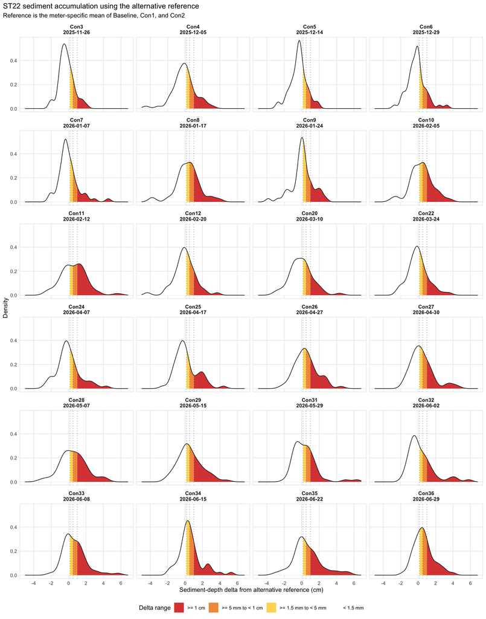

```r
st22_alternative_density_plot <- ggplot(
  st22_alternative_density,
  aes(x = sediment_delta_cm, y = density)
) +
  geom_area(
    aes(fill = delta_band, group = delta_band),
    color = NA,
    alpha = 0.9
  ) +
  geom_line(linewidth = 0.45, color = "grey15") +
  geom_vline(
    xintercept = c(0.15, 0.5, 1),
    color = "grey45",
    linewidth = 0.3,
    linetype = "dotted"
  ) +
  facet_wrap(~ survey_label, ncol = 4) +
  scale_fill_manual(
    values = c(
      ">= 1 cm" = "#d73027",
      ">= 5 mm to < 1 cm" = "#f28e2b",
      ">= 1.5 mm to < 5 mm" = "#ffd54f",
      "< 1.5 mm" = "white"
    ),
    drop = FALSE
  ) +
  scale_x_continuous(
    breaks = seq(
      floor(st22_alternative_delta_limits[1] / 2) * 2,
      ceiling(st22_alternative_delta_limits[2] / 2) * 2,
      by = 2
    )
  ) +
  labs(
    title = "ST22 sediment accumulation using the alternative reference",
    subtitle = "Reference is the meter-specific mean of Baseline, Con1, and Con2",
    x = "Sediment-depth delta from alternative reference (cm)",
    y = "Density",
    fill = "Delta range"
  ) +
  theme_minimal(base_size = 10) +
  theme(
    panel.grid.minor = element_blank(),
    panel.border = element_rect(color = "grey80", fill = NA, linewidth = 0.3),
    strip.text = element_text(face = "bold", size = 8.5),
    legend.position = "bottom",
    plot.title.position = "plot"
  )

st22_alternative_density_plot
```

### Alternative-reference accumulation versus mirrored loss

```r
st22_alternative_max_absolute_delta <-
  max(abs(st22_alternative_deltas$alternative_delta_cm)) + 0.5

st22_alternative_mirrored_density <- st22_alternative_deltas %>%
  group_by(date, survey, survey_n) %>%
  group_modify(~ {
    density_estimate <- density(
      .x$alternative_delta_cm,
      from = -st22_alternative_max_absolute_delta,
      to = st22_alternative_max_absolute_delta,
      n = 2049,
      na.rm = TRUE
    )

    positive_magnitude <- density_estimate$x[
      density_estimate$x >= 0
    ]

    tibble(
      magnitude_cm = positive_magnitude,
      accumulation_density = approx(
        density_estimate$x,
        density_estimate$y,
        xout = positive_magnitude
      )$y,
      mirrored_loss_density = approx(
        density_estimate$x,
        density_estimate$y,
        xout = -positive_magnitude
      )$y
    )
  }) %>%
  ungroup() %>%
  mutate(
    accumulation_exceeds_loss =
      accumulation_density > mirrored_loss_density,
    delta_band = case_when(
      magnitude_cm >= 1 ~ ">= 1 cm",
      magnitude_cm >= 0.5 ~ ">= 5 mm to < 1 cm",
      magnitude_cm >= 0.15 ~ ">= 1.5 mm to < 5 mm",
      TRUE ~ "< 1.5 mm"
    ),
    delta_band = factor(
      delta_band,
      levels = c(
        ">= 1 cm",
        ">= 5 mm to < 1 cm",
        ">= 1.5 mm to < 5 mm",
        "< 1.5 mm"
      )
    ),
    excess_run = cumsum(
      accumulation_exceeds_loss != lag(
        accumulation_exceeds_loss,
        default = first(accumulation_exceeds_loss)
      ) |
        delta_band != lag(delta_band, default = first(delta_band))
    ),
    survey_label = paste0(survey, "\n", format(date, "%Y-%m-%d")),
    survey_label = fct_reorder(survey_label, survey_n),
    .by = c(date, survey, survey_n)
  )

st22_alternative_mirrored_curves <- st22_alternative_mirrored_density %>%
  select(
    date,
    survey,
    survey_n,
    survey_label,
    magnitude_cm,
    accumulation_density,
    mirrored_loss_density
  ) %>%
  pivot_longer(
    c(accumulation_density, mirrored_loss_density),
    names_to = "curve",
    values_to = "density"
  ) %>%
  mutate(
    curve = recode(
      curve,
      accumulation_density = "Accumulation (+delta)",
      mirrored_loss_density = "Mirrored loss (-delta)"
    ),
    curve = factor(
      curve,
      levels = c("Accumulation (+delta)", "Mirrored loss (-delta)")
    )
  )
```

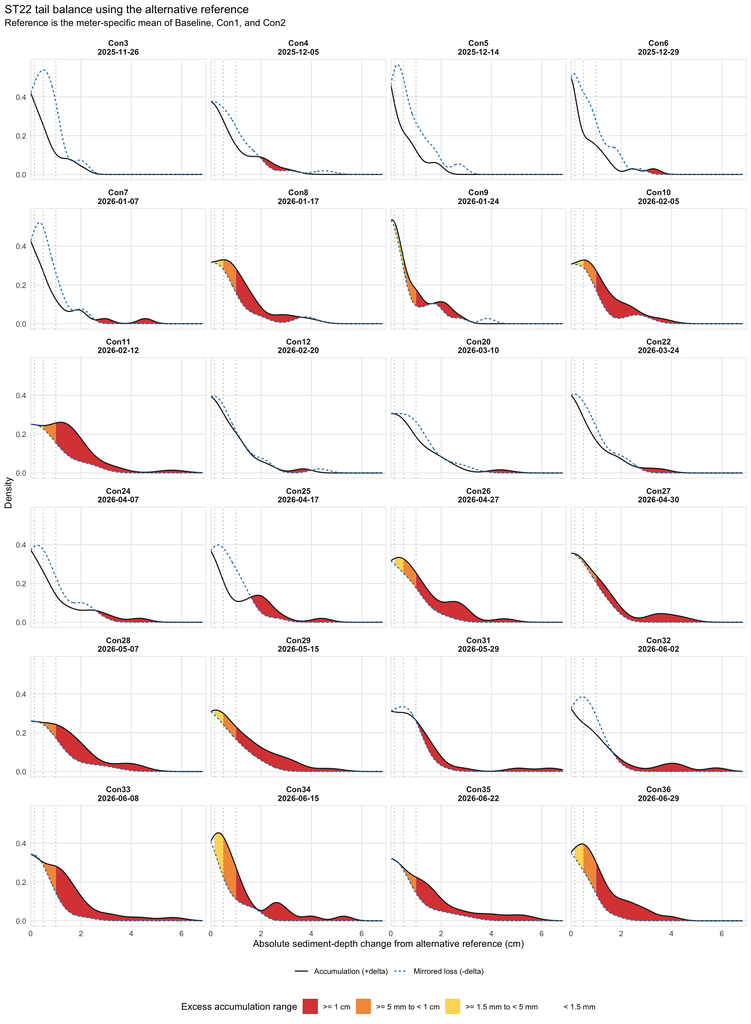

```r
st22_alternative_tail_balance_plot <- ggplot(
  st22_alternative_mirrored_curves,
  aes(x = magnitude_cm, y = density)
) +
  geom_ribbon(
    data = st22_alternative_mirrored_density %>%
      filter(accumulation_exceeds_loss),
    aes(
      x = magnitude_cm,
      ymin = mirrored_loss_density,
      ymax = accumulation_density,
      fill = delta_band,
      group = interaction(delta_band, excess_run)
    ),
    inherit.aes = FALSE,
    alpha = 0.9
  ) +
  geom_line(
    aes(color = curve, linetype = curve),
    linewidth = 0.55
  ) +
  geom_vline(
    xintercept = c(0.15, 0.5, 1),
    color = "grey55",
    linewidth = 0.3,
    linetype = "dotted"
  ) +
  facet_wrap(~ survey_label, ncol = 4) +
  scale_fill_manual(
    values = c(
      ">= 1 cm" = "#d73027",
      ">= 5 mm to < 1 cm" = "#f28e2b",
      ">= 1.5 mm to < 5 mm" = "#ffd54f",
      "< 1.5 mm" = "white"
    ),
    drop = FALSE
  ) +
  scale_color_manual(
    values = c(
      "Accumulation (+delta)" = "grey10",
      "Mirrored loss (-delta)" = "#2c7fb8"
    )
  ) +
  scale_linetype_manual(
    values = c(
      "Accumulation (+delta)" = "solid",
      "Mirrored loss (-delta)" = "22"
    )
  ) +
  scale_x_continuous(
    breaks = seq(0, floor(st22_alternative_max_absolute_delta), by = 2),
    expand = expansion(mult = c(0, 0.02))
  ) +
  labs(
    title = "ST22 tail balance using the alternative reference",
    subtitle = "Reference is the meter-specific mean of Baseline, Con1, and Con2",
    x = "Absolute sediment-depth change from alternative reference (cm)",
    y = "Density",
    fill = "Excess accumulation range",
    color = NULL,
    linetype = NULL
  ) +
  guides(
    color = guide_legend(order = 1),
    linetype = guide_legend(order = 1),
    fill = guide_legend(order = 2)
  ) +
  theme_minimal(base_size = 10) +
  theme(
    panel.grid.minor = element_blank(),
    panel.border = element_rect(color = "grey80", fill = NA, linewidth = 0.3),
    strip.text = element_text(face = "bold", size = 8.5),
    legend.position = "bottom",
    legend.box = "vertical",
    plot.title.position = "plot",
    plot.title = element_text(margin = margin(b = 4)),
    plot.subtitle = element_text(margin = margin(b = 8))
  )

st22_alternative_tail_balance_plot
```

### Reference comparison

```r
st22_reference_comparison <- st22_alternative_deltas %>%
  select(
    date,
    survey,
    survey_n,
    meter,
    official_delta_cm,
    alternative_delta_cm
  ) %>%
  pivot_longer(
    c(official_delta_cm, alternative_delta_cm),
    names_to = "reference",
    values_to = "sediment_delta_cm"
  ) %>%
  mutate(
    reference = recode(
      reference,
      official_delta_cm = "Official baseline",
      alternative_delta_cm = "Baseline-Con1-Con2 average"
    )
  ) %>%
  crossing(tail_balance_thresholds) %>%
  summarize(
    n_meter_positions = n(),
    n_accumulation_exceedances =
      sum(sediment_delta_cm >= threshold_cm),
    pct_accumulation_exceedances =
      mean(sediment_delta_cm >= threshold_cm),
    n_equivalent_losses =
      sum(sediment_delta_cm <= -threshold_cm),
    pct_equivalent_losses =
      mean(sediment_delta_cm <= -threshold_cm),
    tail_balance =
      pct_accumulation_exceedances - pct_equivalent_losses,
    .by = c(
      date,
      survey,
      survey_n,
      reference,
      threshold_cm,
      threshold_label
    )
  ) %>%
  arrange(survey_n, threshold_cm, reference)

st22_reference_comparison
```

```
## # A tibble: 144 × 12
##    date       survey survey_n reference             threshold_cm threshold_label
##    <date>     <chr>     <int> <chr>                        <dbl> <chr>
##  1 2025-11-26 Con3          3 Baseline-Con1-Con2 a…         0.15 1.5 mm
##  2 2025-11-26 Con3          3 Official baseline             0.15 1.5 mm
##  3 2025-11-26 Con3          3 Baseline-Con1-Con2 a…         0.5  5 mm
##  4 2025-11-26 Con3          3 Official baseline             0.5  5 mm
##  5 2025-11-26 Con3          3 Baseline-Con1-Con2 a…         1    1 cm
##  6 2025-11-26 Con3          3 Official baseline             1    1 cm
##  7 2025-12-05 Con4          4 Baseline-Con1-Con2 a…         0.15 1.5 mm
##  8 2025-12-05 Con4          4 Official baseline             0.15 1.5 mm
##  9 2025-12-05 Con4          4 Baseline-Con1-Con2 a…         0.5  5 mm
## 10 2025-12-05 Con4          4 Official baseline             0.5  5 mm
## # ℹ 134 more rows
## # ℹ 6 more variables: n_meter_positions <int>,
## #   n_accumulation_exceedances <int>, pct_accumulation_exceedances <dbl>,
## #   n_equivalent_losses <int>, pct_equivalent_losses <dbl>, tail_balance <dbl>
```

## ST22 tail-balance visualization comparison

The following views use empirical exceedance fractions rather than smoothed density estimates. At magnitude $t$, accumulation exceedance is the fraction of meter positions with $\Delta \ge t$, loss exceedance is the fraction with $\Delta \le -t$, and tail balance is their difference.

```r
st22_reference_deltas_long <- st22_alternative_deltas %>%
  select(
    date,
    survey,
    survey_n,
    meter,
    official_delta_cm,
    alternative_delta_cm
  ) %>%
  pivot_longer(
    c(official_delta_cm, alternative_delta_cm),
    names_to = "reference",
    values_to = "sediment_delta_cm"
  ) %>%
  mutate(
    reference = recode(
      reference,
      official_delta_cm = "Official baseline",
      alternative_delta_cm = "Baseline-Con1-Con2 average"
    ),
    reference = factor(
      reference,
      levels = c("Official baseline", "Baseline-Con1-Con2 average")
    ),
    survey_label = paste0(survey, "\n", format(date, "%Y-%m-%d")),
    survey_label = fct_reorder(survey_label, survey_n)
  )

tail_profile_max_cm <- ceiling(
  max(abs(st22_reference_deltas_long$sediment_delta_cm))
)

tail_profile_thresholds <- tibble(
  threshold_cm = seq(0, tail_profile_max_cm, by = 0.05)
)

st22_empirical_tail_profiles <- crossing(
  st22_reference_deltas_long,
  tail_profile_thresholds
) %>%
  summarize(
    accumulation_fraction = if_else(
      first(threshold_cm) == 0,
      mean(sediment_delta_cm > 0),
      mean(sediment_delta_cm >= threshold_cm)
    ),
    loss_fraction = if_else(
      first(threshold_cm) == 0,
      mean(sediment_delta_cm < 0),
      mean(sediment_delta_cm <= -threshold_cm)
    ),
    tail_balance = accumulation_fraction - loss_fraction,
    .by = c(
      date,
      survey,
      survey_n,
      survey_label,
      reference,
      threshold_cm
    )
  ) %>%
  arrange(reference, survey_n, threshold_cm) %>%
  mutate(
    balance_direction = case_when(
      tail_balance > 0 ~ "Accumulation exceeds loss",
      tail_balance < 0 ~ "Loss exceeds accumulation",
      TRUE ~ "Balanced"
    ),
    balance_direction = factor(
      balance_direction,
      levels = c(
        "Accumulation exceeds loss",
        "Loss exceeds accumulation",
        "Balanced"
      )
    ),
    direction_run = cumsum(
      balance_direction != lag(
        balance_direction,
        default = first(balance_direction)
      )
    ),
    .by = c(reference, survey_n)
  )
```

### Empirical exceedance curves

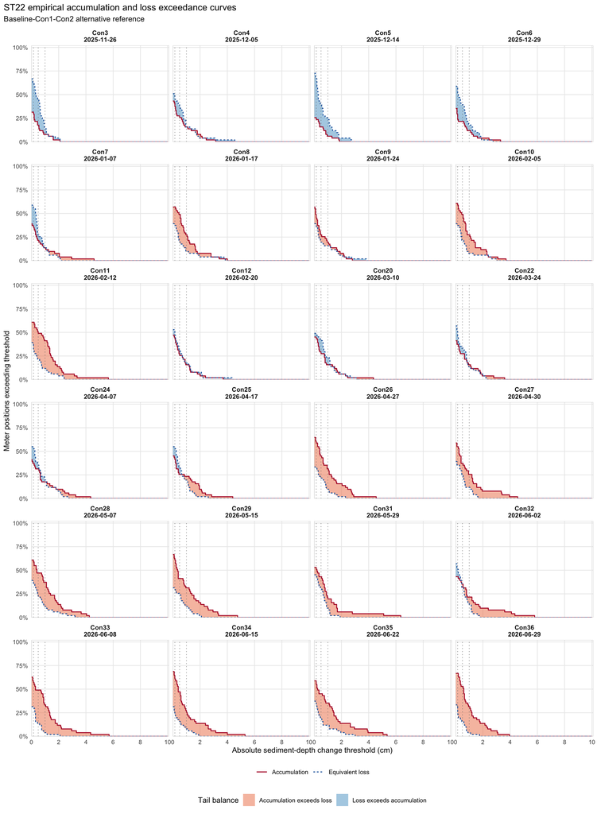

```r
st22_alternative_exceedance_profiles <- st22_empirical_tail_profiles %>%
  filter(reference == "Baseline-Con1-Con2 average")

st22_alternative_exceedance_curves <-
  st22_alternative_exceedance_profiles %>%
  select(
    date,
    survey,
    survey_n,
    survey_label,
    threshold_cm,
    accumulation_fraction,
    loss_fraction
  ) %>%
  pivot_longer(
    c(accumulation_fraction, loss_fraction),
    names_to = "tail",
    values_to = "fraction"
  ) %>%
  mutate(
    tail = recode(
      tail,
      accumulation_fraction = "Accumulation",
      loss_fraction = "Equivalent loss"
    ),
    tail = factor(tail, levels = c("Accumulation", "Equivalent loss"))
  )

st22_exceedance_curve_plot <- ggplot(
  st22_alternative_exceedance_curves,
  aes(x = threshold_cm, y = fraction)
) +
  geom_ribbon(
    data = st22_alternative_exceedance_profiles %>%
      filter(balance_direction != "Balanced"),
    aes(
      x = threshold_cm,
      ymin = pmin(accumulation_fraction, loss_fraction),
      ymax = pmax(accumulation_fraction, loss_fraction),
      fill = balance_direction,
      group = interaction(survey_n, direction_run)
    ),
    inherit.aes = FALSE,
    alpha = 0.55
  ) +
  geom_step(
    aes(color = tail, linetype = tail),
    linewidth = 0.55,
    direction = "hv"
  ) +
  geom_vline(
    xintercept = c(0.15, 0.5, 1),
    color = "grey45",
    linewidth = 0.3,
    linetype = "dotted"
  ) +
  facet_wrap(~ survey_label, ncol = 4) +
  scale_x_continuous(
    limits = c(0, tail_profile_max_cm),
    breaks = seq(0, tail_profile_max_cm, by = 2),
    expand = expansion(mult = c(0, 0.01))
  ) +
  scale_y_continuous(
    labels = scales::label_percent(accuracy = 1),
    limits = c(0, 1),
    expand = expansion(mult = c(0, 0.02))
  ) +
  scale_color_manual(
    values = c("Accumulation" = "#b2182b", "Equivalent loss" = "#2166ac")
  ) +
  scale_linetype_manual(
    values = c("Accumulation" = "solid", "Equivalent loss" = "22")
  ) +
  scale_fill_manual(
    values = c(
      "Accumulation exceeds loss" = "#ef8a62",
      "Loss exceeds accumulation" = "#67a9cf"
    )
  ) +
  labs(
    title = "ST22 empirical accumulation and loss exceedance curves",
    subtitle = "Baseline-Con1-Con2 alternative reference",
    x = "Absolute sediment-depth change threshold (cm)",
    y = "Meter positions exceeding threshold",
    color = NULL,
    linetype = NULL,
    fill = "Tail balance"
  ) +
  guides(
    color = guide_legend(order = 1),
    linetype = guide_legend(order = 1),
    fill = guide_legend(order = 2)
  ) +
  theme_minimal(base_size = 10) +
  theme(
    panel.grid.minor = element_blank(),
    panel.border = element_rect(color = "grey80", fill = NA, linewidth = 0.3),
    strip.text = element_text(face = "bold", size = 8.5),
    legend.position = "bottom",
    legend.box = "vertical",
    plot.title.position = "plot"
  )

st22_exceedance_curve_plot
```

### Net accumulation-exceedance curves

This is the direct difference between the two curves above. At each sediment- change threshold, the curve is the percentage of meter positions exceeding the threshold through accumulation minus the percentage exceeding the same threshold through loss. Positive values indicate excess accumulation, negative values indicate excess loss, and zero indicates equal prevalence. The view is limited to 3 cm so that the regulatory thresholds and the main body of the empirical distributions remain legible.

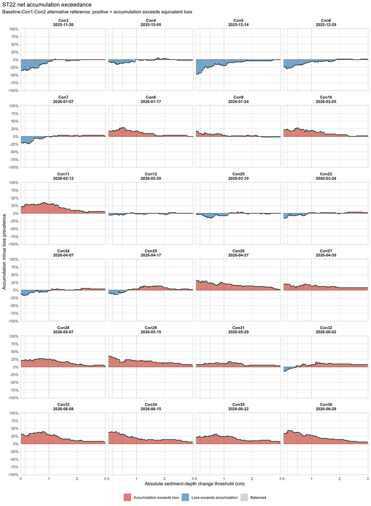

```r
st22_net_exceedance_profiles <- st22_alternative_exceedance_profiles %>%
  filter(threshold_cm <= 3)

st22_net_exceedance_curve_plot <- ggplot(
  st22_net_exceedance_profiles,
  aes(x = threshold_cm, y = tail_balance)
) +
  geom_hline(yintercept = 0, color = "grey35", linewidth = 0.4) +
  geom_ribbon(
    aes(
      ymin = pmin(tail_balance, 0),
      ymax = pmax(tail_balance, 0),
      fill = balance_direction,
      group = interaction(survey_n, direction_run)
    ),
    alpha = 0.7
  ) +
  geom_step(
    color = "grey15",
    linewidth = 0.55,
    direction = "hv"
  ) +
  geom_vline(
    xintercept = c(0.15, 0.5, 1),
    color = "grey45",
    linewidth = 0.3,
    linetype = "dotted"
  ) +
  facet_wrap(~ survey_label, ncol = 4) +
  scale_x_continuous(
    limits = c(0, 3),
    breaks = 0:3,
    expand = expansion(mult = c(0, 0.01))
  ) +
  scale_y_continuous(
    labels = scales::label_percent(accuracy = 1),
    limits = c(-1, 1),
    breaks = seq(-1, 1, by = 0.25),
    expand = expansion(mult = c(0.01, 0.01))
  ) +
  scale_fill_manual(
    values = c(
      "Accumulation exceeds loss" = "#d6604d",
      "Loss exceeds accumulation" = "#4393c3",
      "Balanced" = "grey80"
    ),
    drop = TRUE
  ) +
  labs(
    title = "ST22 net accumulation exceedance",
    subtitle = paste(
      "Baseline-Con1-Con2 alternative reference; positive = accumulation",
      "exceeds equivalent loss"
    ),
    x = "Absolute sediment-depth change threshold (cm)",
    y = "Accumulation minus loss prevalence",
    fill = NULL
  ) +
  theme_minimal(base_size = 10) +
  theme(
    panel.grid.minor = element_blank(),
    panel.border = element_rect(color = "grey80", fill = NA, linewidth = 0.3),
    strip.text = element_text(face = "bold", size = 8.5),
    legend.position = "bottom",
    plot.title.position = "plot"
  )

st22_net_exceedance_curve_plot
```

### Smoothed cumulative net exceedance

```r
smooth_tail_profile <- function(delta, thresholds = seq(0, 3, by = 0.01)) {
  kernel <- density(delta, bw = "nrd0", n = 4096, cut = 4)
  interval_area <- diff(kernel$x) *
    (head(kernel$y, -1) + tail(kernel$y, -1)) / 2
  kernel_cdf <- c(0, cumsum(interval_area))
  kernel_cdf <- kernel_cdf / max(kernel_cdf)
  cdf_at <- approxfun(
    kernel$x,
    kernel_cdf,
    yleft = 0,
    yright = 1
  )

  tibble(
    threshold_cm = thresholds,
    smoothed_accumulation_fraction = 1 - cdf_at(thresholds),
    smoothed_loss_fraction = cdf_at(-thresholds),
    smoothed_tail_balance =
      smoothed_accumulation_fraction - smoothed_loss_fraction
  )
}

st22_smoothed_net_profiles <- st22_alternative_deltas %>%
  group_by(date, survey, survey_n) %>%
  group_modify(~ smooth_tail_profile(.x$alternative_delta_cm)) %>%
  ungroup() %>%
  mutate(
    survey_label = paste0(survey, "\n", format(date, "%Y-%m-%d")),
    survey_label = fct_reorder(survey_label, survey_n),
    balance_direction = if_else(
      smoothed_tail_balance >= 0,
      "Accumulation exceeds loss",
      "Loss exceeds accumulation"
    ),
    direction_run = cumsum(
      balance_direction != lag(
        balance_direction,
        default = first(balance_direction)
      )
    ),
    .by = survey_n
  )

st22_empirical_regulatory_points <-
  st22_alternative_exceedance_profiles %>%
  filter(threshold_cm %in% c(0.15, 0.5, 1))
```

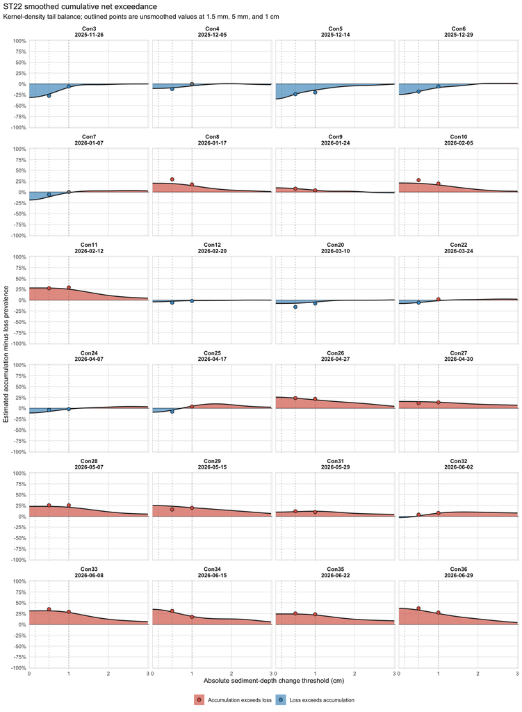

```r
st22_smoothed_net_exceedance_plot <- ggplot(
  st22_smoothed_net_profiles,
  aes(x = threshold_cm, y = smoothed_tail_balance)
) +
  geom_hline(yintercept = 0, color = "grey35", linewidth = 0.4) +
  geom_ribbon(
    aes(
      ymin = pmin(smoothed_tail_balance, 0),
      ymax = pmax(smoothed_tail_balance, 0),
      fill = balance_direction,
      group = interaction(survey_n, direction_run)
    ),
    alpha = 0.65
  ) +
  geom_line(color = "grey15", linewidth = 0.65) +
  geom_vline(
    xintercept = c(0.15, 0.5, 1),
    color = "grey45",
    linewidth = 0.3,
    linetype = "dotted"
  ) +
  geom_point(
    data = st22_empirical_regulatory_points,
    aes(
      x = threshold_cm,
      y = tail_balance,
      fill = balance_direction
    ),
    inherit.aes = FALSE,
    shape = 21,
    color = "grey10",
    stroke = 0.45,
    size = 2.2
  ) +
  facet_wrap(~ survey_label, ncol = 4) +
  scale_x_continuous(
    limits = c(0, 3),
    breaks = 0:3,
    expand = expansion(mult = c(0, 0.01))
  ) +
  scale_y_continuous(
    labels = scales::label_percent(accuracy = 1),
    limits = c(-1, 1),
    breaks = seq(-1, 1, by = 0.25),
    expand = expansion(mult = c(0.01, 0.01))
  ) +
  scale_fill_manual(
    values = c(
      "Accumulation exceeds loss" = "#d6604d",
      "Loss exceeds accumulation" = "#4393c3"
    )
  ) +
  labs(
    title = "ST22 smoothed cumulative net exceedance",
    subtitle = paste(
      "Kernel-density tail balance; outlined points are unsmoothed values at",
      "1.5 mm, 5 mm, and 1 cm"
    ),
    x = "Absolute sediment-depth change threshold (cm)",
    y = "Estimated accumulation minus loss prevalence",
    fill = NULL
  ) +
  theme_minimal(base_size = 10) +
  theme(
    panel.grid.minor = element_blank(),
    panel.border = element_rect(color = "grey80", fill = NA, linewidth = 0.3),
    strip.text = element_text(face = "bold", size = 8.5),
    legend.position = "bottom",
    plot.title.position = "plot"
  )

st22_smoothed_net_exceedance_plot
```

### Mirrored cumulative accumulation and loss

```r
st22_smoothed_mirrored_profiles <- st22_smoothed_net_profiles %>%
  select(
    date,
    survey,
    survey_n,
    survey_label,
    threshold_cm,
    smoothed_accumulation_fraction,
    smoothed_loss_fraction
  ) %>%
  pivot_longer(
    c(smoothed_accumulation_fraction, smoothed_loss_fraction),
    names_to = "tail",
    values_to = "fraction"
  ) %>%
  mutate(
    tail = recode(
      tail,
      smoothed_accumulation_fraction = "Accumulation",
      smoothed_loss_fraction = "Equivalent loss"
    ),
    tail = factor(tail, levels = c("Accumulation", "Equivalent loss")),
    signed_fraction = if_else(tail == "Accumulation", fraction, -fraction)
  )

st22_empirical_mirrored_points <- st22_empirical_regulatory_points %>%
  select(
    date,
    survey,
    survey_n,
    survey_label,
    threshold_cm,
    accumulation_fraction,
    loss_fraction
  ) %>%
  pivot_longer(
    c(accumulation_fraction, loss_fraction),
    names_to = "tail",
    values_to = "fraction"
  ) %>%
  mutate(
    tail = recode(
      tail,
      accumulation_fraction = "Accumulation",
      loss_fraction = "Equivalent loss"
    ),
    tail = factor(tail, levels = c("Accumulation", "Equivalent loss")),
    signed_fraction = if_else(tail == "Accumulation", fraction, -fraction)
  )
```

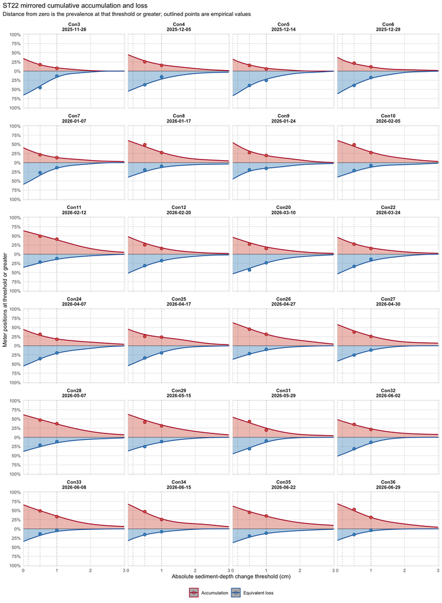

```r
st22_mirrored_cumulative_plot <- ggplot(
  st22_smoothed_mirrored_profiles,
  aes(
    x = threshold_cm,
    y = signed_fraction,
    color = tail,
    fill = tail,
    group = tail
  )
) +
  geom_hline(yintercept = 0, color = "grey35", linewidth = 0.4) +
  geom_area(alpha = 0.4, position = "identity") +
  geom_line(linewidth = 0.7) +
  geom_vline(
    xintercept = c(0.15, 0.5, 1),
    color = "grey45",
    linewidth = 0.3,
    linetype = "dotted"
  ) +
  geom_point(
    data = st22_empirical_mirrored_points,
    aes(
      x = threshold_cm,
      y = signed_fraction,
      color = tail,
      fill = tail
    ),
    inherit.aes = FALSE,
    shape = 21,
    stroke = 0.5,
    size = 2.2
  ) +
  facet_wrap(~ survey_label, ncol = 4) +
  scale_x_continuous(
    limits = c(0, 3),
    breaks = 0:3,
    expand = expansion(mult = c(0, 0.01))
  ) +
  scale_y_continuous(
    labels = ~ scales::percent(abs(.x), accuracy = 1),
    limits = c(-1, 1),
    breaks = seq(-1, 1, by = 0.25),
    expand = expansion(mult = c(0.01, 0.01))
  ) +
  scale_color_manual(
    values = c("Accumulation" = "#b2182b", "Equivalent loss" = "#2166ac")
  ) +
  scale_fill_manual(
    values = c("Accumulation" = "#d6604d", "Equivalent loss" = "#4393c3")
  ) +
  labs(
    title = "ST22 mirrored cumulative accumulation and loss",
    subtitle = paste(
      "Distance from zero is the prevalence at that threshold or greater;",
      "outlined points are empirical values"
    ),
    x = "Absolute sediment-depth change threshold (cm)",
    y = "Meter positions at threshold or greater",
    color = NULL,
    fill = NULL
  ) +
  guides(fill = "none") +
  theme_minimal(base_size = 10) +
  theme(
    panel.grid.minor = element_blank(),
    panel.border = element_rect(color = "grey80", fill = NA, linewidth = 0.3),
    strip.text = element_text(face = "bold", size = 8.5),
    legend.position = "bottom",
    plot.title.position = "plot"
  )

st22_mirrored_cumulative_plot
```

### Mirrored empirical curves with net balance

The red and blue curves remain the actual empirical accumulation and loss prevalences. The black curve overlays their difference: accumulation prevalence minus equivalent-loss prevalence.

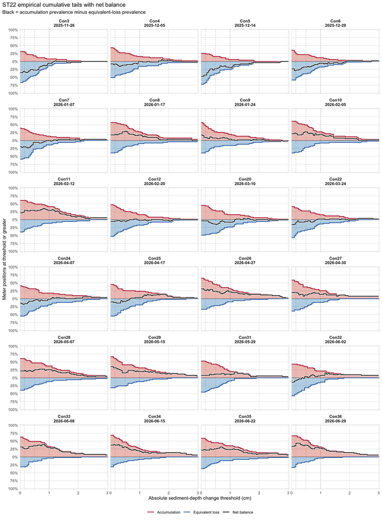

```r
st22_empirical_mirrored_profiles <-
  st22_alternative_exceedance_profiles %>%
  filter(threshold_cm <= 3) %>%
  select(
    date,
    survey,
    survey_n,
    survey_label,
    threshold_cm,
    accumulation_fraction,
    loss_fraction
  ) %>%
  pivot_longer(
    c(accumulation_fraction, loss_fraction),
    names_to = "tail",
    values_to = "fraction"
  ) %>%
  mutate(
    tail = recode(
      tail,
      accumulation_fraction = "Accumulation",
      loss_fraction = "Equivalent loss"
    ),
    tail = factor(tail, levels = c("Accumulation", "Equivalent loss")),
    signed_fraction = if_else(tail == "Accumulation", fraction, -fraction),
    threshold_end = lead(threshold_cm, default = 3),
    .by = c(survey_n, tail)
  )

st22_mirrored_empirical_net_plot <- ggplot() +
  geom_hline(yintercept = 0, color = "grey35", linewidth = 0.4) +
  geom_rect(
    data = st22_empirical_mirrored_profiles,
    aes(
      xmin = threshold_cm,
      xmax = threshold_end,
      ymin = pmin(signed_fraction, 0),
      ymax = pmax(signed_fraction, 0),
      fill = tail
    ),
    alpha = 0.4,
    color = NA
  ) +
  geom_step(
    data = st22_empirical_mirrored_profiles,
    aes(
      x = threshold_cm,
      y = signed_fraction,
      color = tail,
      group = tail
    ),
    linewidth = 0.65,
    direction = "hv"
  ) +
  geom_step(
    data = st22_net_exceedance_profiles,
    aes(x = threshold_cm, y = tail_balance),
    color = "white",
    linewidth = 1.4,
    direction = "hv"
  ) +
  geom_step(
    data = st22_net_exceedance_profiles,
    aes(x = threshold_cm, y = tail_balance, color = "Net balance"),
    linewidth = 0.7,
    direction = "hv"
  ) +
  geom_vline(
    xintercept = c(0.15, 0.5, 1),
    color = "grey45",
    linewidth = 0.3,
    linetype = "dotted"
  ) +
  facet_wrap(~ survey_label, ncol = 4) +
  scale_x_continuous(
    limits = c(0, 3),
    breaks = 0:3,
    expand = expansion(mult = c(0, 0.01))
  ) +
  scale_y_continuous(
    labels = ~ scales::percent(abs(.x), accuracy = 1),
    limits = c(-1, 1),
    breaks = seq(-1, 1, by = 0.25),
    expand = expansion(mult = c(0.01, 0.01))
  ) +
  scale_color_manual(
    values = c(
      "Accumulation" = "#b2182b",
      "Equivalent loss" = "#2166ac",
      "Net balance" = "#1a1a1a"
    )
  ) +
  scale_fill_manual(
    values = c("Accumulation" = "#d6604d", "Equivalent loss" = "#4393c3")
  ) +
  labs(
    title = "ST22 empirical cumulative tails with net balance",
    subtitle = "Black = accumulation prevalence minus equivalent-loss prevalence",
    x = "Absolute sediment-depth change threshold (cm)",
    y = "Meter positions at threshold or greater",
    color = NULL,
    fill = NULL
  ) +
  guides(fill = "none") +
  theme_minimal(base_size = 10) +
  theme(
    panel.grid.minor = element_blank(),
    panel.border = element_rect(color = "grey80", fill = NA, linewidth = 0.3),
    strip.text = element_text(face = "bold", size = 8.5),
    legend.position = "bottom",
    plot.title.position = "plot"
  )

st22_mirrored_empirical_net_plot
```

### Animated empirical curves with maximum-net memory

The red, blue, and black curves show the current survey. At each absolute sediment-depth threshold, the dashed green curve records the largest signed net balance observed from Con3 through the current survey. It therefore acts as a threshold-specific memory of the strongest accumulation-dominant result seen so far.

```r
st22_animation_frames <- st22_net_exceedance_profiles %>%
  distinct(survey_n, survey_label) %>%
  arrange(survey_n) %>%
  mutate(
    frame_label = paste0(
      str_replace(survey_label, "\\n", "  |  ")
    ),
    frame_label = factor(frame_label, levels = frame_label)
  )

st22_animation_tails <- st22_empirical_mirrored_profiles %>%
  left_join(st22_animation_frames, by = c("survey_n", "survey_label"))

st22_animation_net <- st22_net_exceedance_profiles %>%
  left_join(st22_animation_frames, by = c("survey_n", "survey_label"))

st22_animation_max_net <- st22_animation_net %>%
  arrange(threshold_cm, survey_n) %>%
  mutate(
    maximum_net_to_date = cummax(tail_balance),
    .by = threshold_cm
  ) %>%
  arrange(survey_n, threshold_cm)
```